# R Notebook

Energy Dataset: The Dataset for this assignment is a modified version of a subset of data used in Candanedo et al, 2017. The experimental data have been used to create models of energy use of appliances in a low-energy house. The modified Dataset provides the energy use of Appliances (denoted as Y) using 671 samples. The Dataset comprises 5 features (variables), which are denoted as X1, X2, X3, X4 and X5. The details about these variables are given below: X1: Temperature in kitchen area, in Celsius X2: Humidity in kitchen area, given as a percentage X3: Temperature outside (from weather station), in Celsius X4: Humidity outside (from weather station), given as a percentage X5: Visibility (from weather station), in km Y: Appliances, energy use, in Wh For more information about the variables see Candanedo et al, 2017

Assignment tasks ##T1. Understand the data ##(i) Download the txt file (ENB_2023.txt) from CloudDeakin and save it to your R working directory.

```r
source_path <- "C:\\Users\\Dell\\OneDrive\\Documents\\Deakin\\ENB_2023.txt"

destination_path <-getwd()

# Use file.copy to move or copy the file to the destination
file.copy(source_path, destination_path, overwrite = TRUE)
```

```
[1] TRUE
```

```r
# Check if the file has been moved/copied successfully
if (file.exists(file.path(destination_path, "ENB_2023.txt"))) {
  cat("File moved/copied successfully to the working directory.\n")
} else {
  cat("Error moving/copying the file.\n")
}
```

```
File moved/copied successfully to the working directory.
```

##(ii) Assign the data to a matrix, e.g. using the.data <- as.matrix(read.table(“ENB_2023.txt”))

```r
my_data <- as.matrix(read.table("ENB_2023.txt"))

print(my_data)
```

[output not shown]

[output cut: 153 more lines]

##(iii) The variable of interest is Y (Appliances). To investigate Y, generate a subset of 340 with numerical data e.g. using: my.data <- the.data[sample(1:671,340),c(1:6)]

```r
set.seed(123)  # for reproducibility
my.data <- my_data[sample(1:nrow(my_data), 340), c(1:6)]
print(head(my.data))
```

```
           V1       V2       V3       V4       V5 V6
[1,] 17.78019 32.32880 1.308541 85.33648 37.78233 40
[2,] 19.03541 34.45179 2.828890 78.89180 23.79041 60
[3,] 18.88490 43.59857 3.438658 88.79173 23.89826 50
[4,] 18.63761 41.86183 1.687212 81.50000 35.66200 50
[5,] 15.58861 38.76055 3.441135 85.13934 24.83406 40
[6,] 18.64463 46.71261 4.046833 80.55984 38.34299 30
```

##Load the Libraries

```r
library(ggplot2)
library(RColorBrewer)
library(moments)
library(grid)
```

Scatter Plots

```r
# Scatter Plots
par(mfrow = c(2, 3))  # Set up a 2x3 layout for the plots

# Scatter Plot for X1 vs. Y
plot(my.data[, 1], my.data[, 6],main = "V1 vs Y", xlab = "V1", ylab = "Y")
# Scatter Plot for X2 vs. Y
plot(my.data[, 2], my.data[, 6], main = "V2 vs Y", xlab = "V2", ylab = "Y")
```

```r
# Scatter Plot for X3 vs. Y
plot(my.data[, 3], my.data[, 6], main = "V3 vs Y", xlab = "V3", ylab = "Y")

# Scatter Plot for X4 vs. Y
plot(my.data[, 4], my.data[, 6], main = "V4 vs Y", xlab = "V4", ylab = "Y")
```

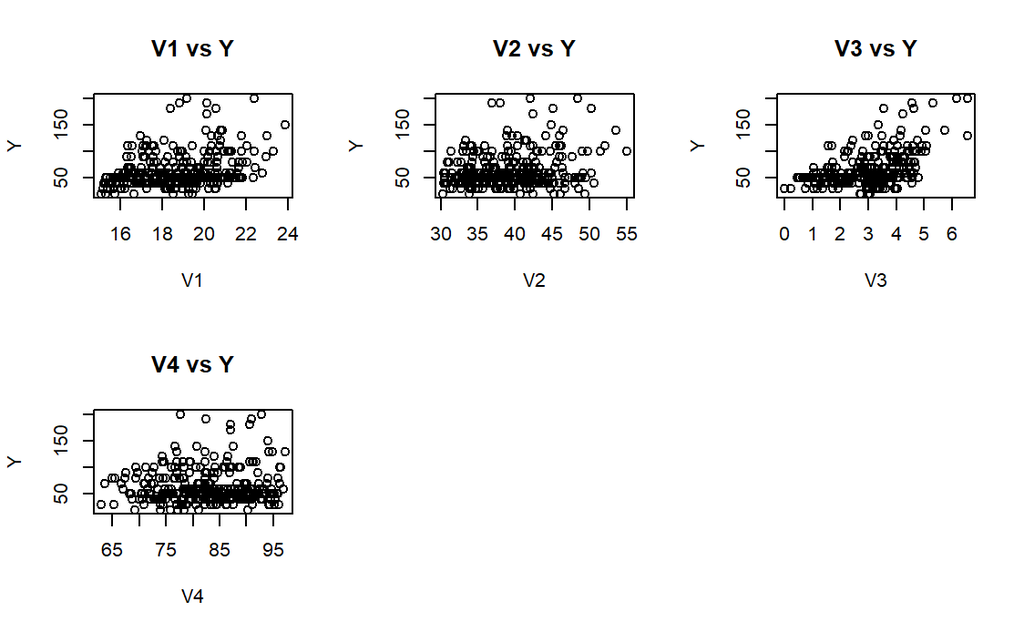

```r
# Scatter Plot for X5 vs. Y
plot(my.data[, 5], my.data[, 6], main = "V5 vs Y", xlab = "V5", ylab = "Y")
```

[output not shown]

##HISTOGRAMS

```r
# Histograms
par(mfrow = c(2, 3))  # Reset the layout for histograms

# Histogram for X1
hist(my.data[, 1], main = "Histogram for X1", xlab = "V1", col = "lightblue", border = "black")

# Histogram for X2
hist(my.data[, 2], main = "Histogram for X2", xlab = "V2", col = "lightgreen", border = "black")
```

```r
# Histogram for X3
hist(my.data[, 3], main = "Histogram for X3", xlab = "V3", col = "blue", border = "black")

# Histogram for X4
hist(my.data[, 4], main = "Histogram for X4", xlab = "V4", col = "pink", border = "black")
```

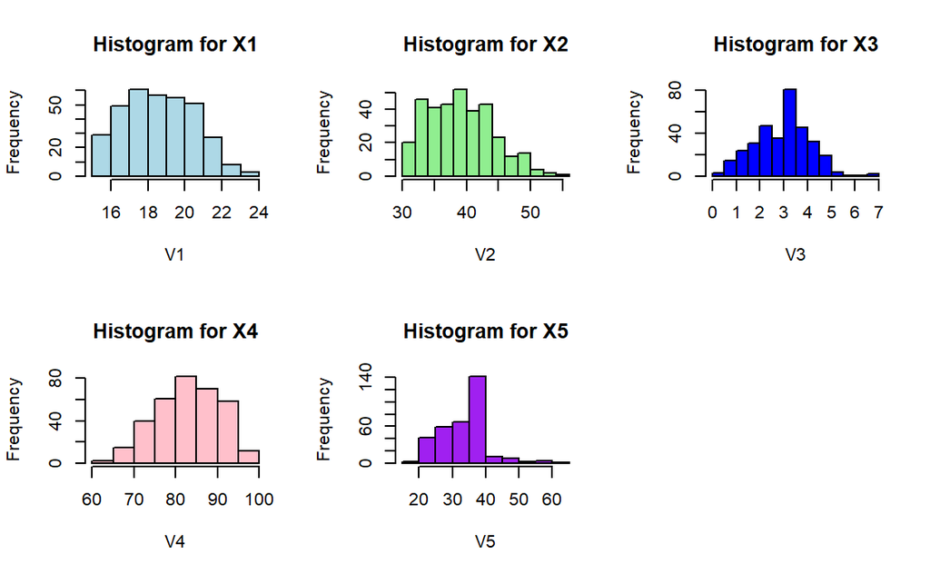

```r
# Histogram for X5
hist(my.data[, 5], main = "Histogram for X5", xlab = "V5", col = "purple", border = "black")

# Histogram for Y
hist(my.data[, 6], main = "Histogram for Y", xlab = "Y", col = "green", border = "black")
```

[output not shown]